# COVID-19 case numbers in British Columbia

Capstone project: BIDA 302

Anthony Bassey

## Background

As the COVID-19 pandemic enters its next phase, the number of cases in British Columbia is increasing.

Here are two charts by Jens von Bergmann:

### BC weekly cases

https://twitter.com/vb_jens/status/1298407214189690880?s=20

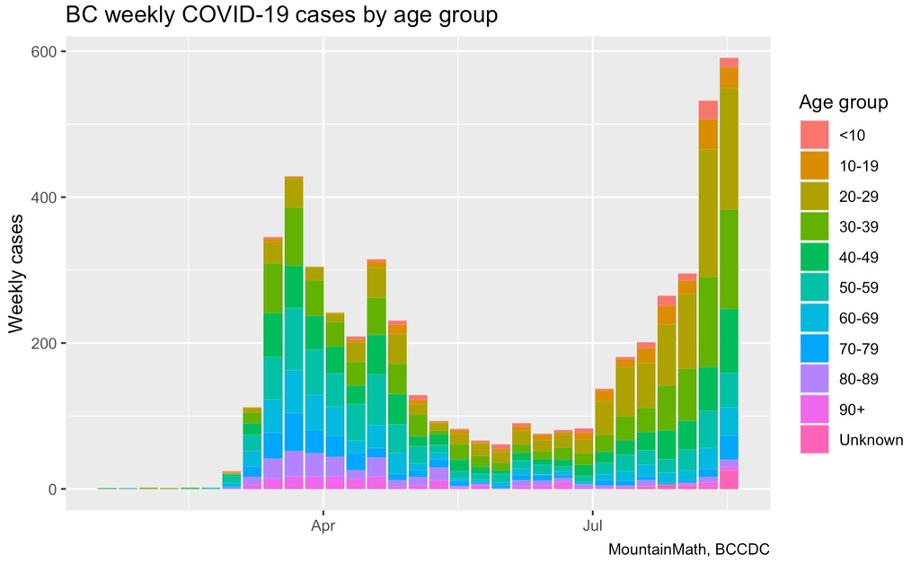

BC weekly cases by age group

# Preparing the environment

#### Install Packages and Load libraries

For this project, we will use the tidyverse, ggplot2, readr and lubridate libraries for our analysis,

```r
#install.packages("tidyverse")
#install.packages("readr")

library(ggplot2)
library(tidyverse)
library(readr)
library(lubridate)
```

# Working on the 1st question

This would be a chart showing the number of cases based on the reported dates and age groups.

#### Approach

We need to read the csv files into our project, then filter for cases in BC, and then show our data in a histogram to show the distribution of cases.

Read the file in

```r
# Read in csv files
popest <- read_csv("Population_Estimates.csv", col_names = TRUE)
coviddash <- read_csv("BCCDC_COVID19_Dashboard_Case_Details_2021-11-28_22-02.csv", col_names = TRUE)
```

We can view our file that’s been read-in. We can see the head, tail, summary statistics, etc.

```r
# View Data
head(coviddash)
```

```
## # A tibble: 6 × 5
##   Reported_Date HA                Sex   Age_Group Classification_Reported
##   <date>        <chr>             <chr> <chr>     <chr>
## 1 2020-01-29    Out of Canada     M     40-49     Lab-diagnosed
## 2 2020-02-06    Vancouver Coastal F     50-59     Lab-diagnosed
## 3 2020-02-10    Out of Canada     F     20-29     Lab-diagnosed
## 4 2020-02-10    Out of Canada     M     30-39     Lab-diagnosed
## 5 2020-02-18    Interior          F     30-39     Lab-diagnosed
## 6 2020-02-24    Fraser            M     40-49     Lab-diagnosed
```

```r
tail(coviddash)
```

```
## # A tibble: 6 × 5
##   Reported_Date HA               Sex   Age_Group Classification_Reported
##   <date>        <chr>            <chr> <chr>     <chr>
## 1 2021-11-25    Interior         F     10-19     Lab-diagnosed
## 2 2021-11-25    Vancouver Island M     20-29     Lab-diagnosed
## 3 2021-11-25    Interior         F     50-59     Lab-diagnosed
## 4 2021-11-25    Interior         M     <10       Lab-diagnosed
## 5 2021-11-25    Vancouver Island M     10-19     Lab-diagnosed
## 6 2021-11-25    Northern         M     80-89     Lab-diagnosed
```

```r
summary(coviddash)
```

```
##  Reported_Date             HA                Sex             Age_Group
##  Min.   :2020-01-29   Length:217099      Length:217099      Length:217099
##  1st Qu.:2021-01-03   Class :character   Class :character   Class :character
##  Median :2021-04-08   Mode  :character   Mode  :character   Mode  :character
##  Mean   :2021-04-16
##  3rd Qu.:2021-08-26
##  Max.   :2021-11-25
##  Classification_Reported
##  Length:217099
##  Class :character
##  Mode  :character
##
##
##
```

```r
str(coviddash)
```

```
## spec_tbl_df [217,099 × 5] (S3: spec_tbl_df/tbl_df/tbl/data.frame)
##  $ Reported_Date          : Date[1:217099], format: "2020-01-29" "2020-02-06" ...
##  $ HA                     : chr [1:217099] "Out of Canada" "Vancouver Coastal" "Out of Canada" "Out of Canada" ...
##  $ Sex                    : chr [1:217099] "M" "F" "F" "M" ...
##  $ Age_Group              : chr [1:217099] "40-49" "50-59" "20-29" "30-39" ...
##  $ Classification_Reported: chr [1:217099] "Lab-diagnosed" "Lab-diagnosed" "Lab-diagnosed" "Lab-diagnosed" ...
##  - attr(*, "spec")=
##   .. cols(
##   ..   Reported_Date = col_date(format = ""),
##   ..   HA = col_character(),
##   ..   Sex = col_character(),
##   ..   Age_Group = col_character(),
##   ..   Classification_Reported = col_character()
##   .. )
##  - attr(*, "problems")=<externalptr>
```

```r
# Filter Data for BC stats
covgg <- coviddash %>%
  filter(Reported_Date >= "2020-01-01", Reported_Date <= "2020-08-25") %>%
  mutate(inf_count = 1) %>% group_by(Reported_Date, Age_Group) %>% summarise(Age_Group, num_inf = sum(inf_count)) %>% ungroup()
covgg
```

```
## # A tibble: 5,319 × 3
##    Reported_Date Age_Group num_inf
##    <date>        <chr>       <dbl>
##  1 2020-01-29    40-49           1
##  2 2020-02-06    50-59           1
##  3 2020-02-10    20-29           1
##  4 2020-02-10    30-39           1
##  5 2020-02-18    30-39           1
##  6 2020-02-24    30-39           1
##  7 2020-02-24    40-49           1
##  8 2020-03-03    30-39           1
##  9 2020-03-03    50-59           1
## 10 2020-03-03    60-69           2
## # … with 5,309 more rows
```

```r
tail(covgg)
```

```
## # A tibble: 6 × 3
##   Reported_Date Age_Group num_inf
##   <date>        <chr>       <dbl>
## 1 2020-08-25    50-59           6
## 2 2020-08-25    50-59           6
## 3 2020-08-25    50-59           6
## 4 2020-08-25    60-69           3
## 5 2020-08-25    60-69           3
## 6 2020-08-25    60-69           3
```

We plot our data as a histogram using geom_histogram() to show the distribution of cases by Age Group.

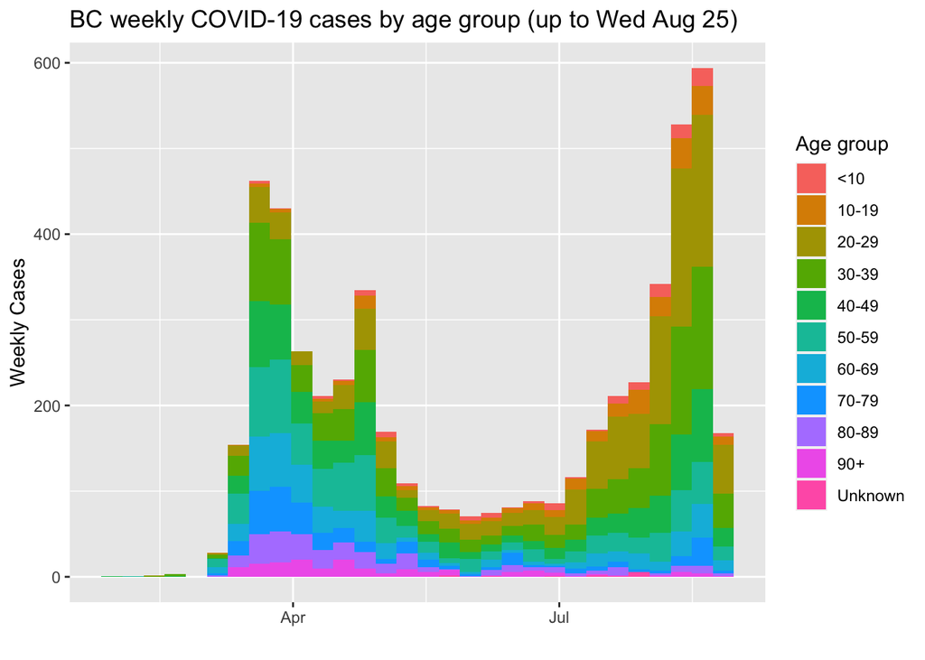

```r
# Plot Data
covplot <- ggplot(covgg, aes(x= Reported_Date, fill = Age_Group)) +
  geom_histogram() + labs(fill = "Age group") +
  #Add Labels & Title
  xlab("") + ylab("Weekly Cases") + ggtitle("BC weekly COVID-19 cases by age group (up to Wed Aug 25)")
covplot
```

We can mutate and then filter our data to get the week and number of cases based on the week,

```r
# Plot Data
plotexp <- coviddash %>% filter(Reported_Date >= "2020-01-01", Reported_Date <= "2020-08-25") %>% mutate(ref_date = week(ymd(Reported_Date))) %>% select(-Reported_Date) %>% mutate(inf1 = 1) %>% group_by(ref_date, Age_Group) %>% summarise(Age_Group, numinf1 = sum(inf1))
tail(plotexp)
```

```
## # A tibble: 6 × 3
## # Groups:   ref_date, Age_Group [2]
##   ref_date Age_Group numinf1
##      <dbl> <chr>       <dbl>
## 1       34 80-89          10
## 2       34 80-89          10
## 3       34 90+             4
## 4       34 90+             4
## 5       34 90+             4
## 6       34 90+             4
```

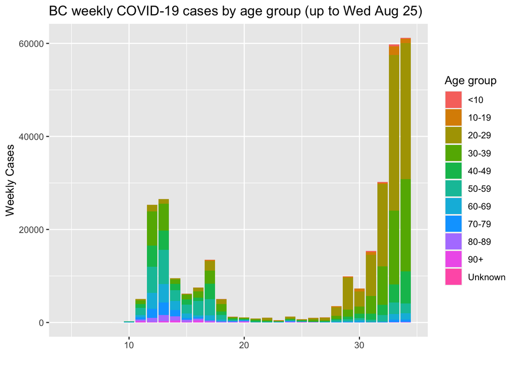

```r
ggplot(plotexp, aes(x= ref_date, fill = Age_Group)) +
  geom_col(aes(y = numinf1)) + labs(fill = "Age group") +
  #Add Labels & Title
  xlab("") + ylab("Weekly Cases") + ggtitle("BC weekly COVID-19 cases by age group (up to Wed Aug 25)")
```

however, this approach would only be looking at x values on a discrete scale, whereas we want to plot our values on a continuous scale.

```r
plotexp2 <- coviddash %>% filter(Reported_Date >= "2020-01-01", Reported_Date <= "2021-11-28") %>% mutate(ref_date = week(ymd(Reported_Date))) %>% select(-Reported_Date) %>% mutate(inf1 = 1) %>% group_by(ref_date, Age_Group) %>% summarise(Age_Group, numinf1 = sum(inf1))
tail(plotexp2)
```

```
## # A tibble: 6 × 3
## # Groups:   ref_date, Age_Group [1]
##   ref_date Age_Group numinf1
##      <dbl> <chr>       <dbl>
## 1       53 90+            25
## 2       53 90+            25
## 3       53 90+            25
## 4       53 90+            25
## 5       53 90+            25
## 6       53 90+            25
```

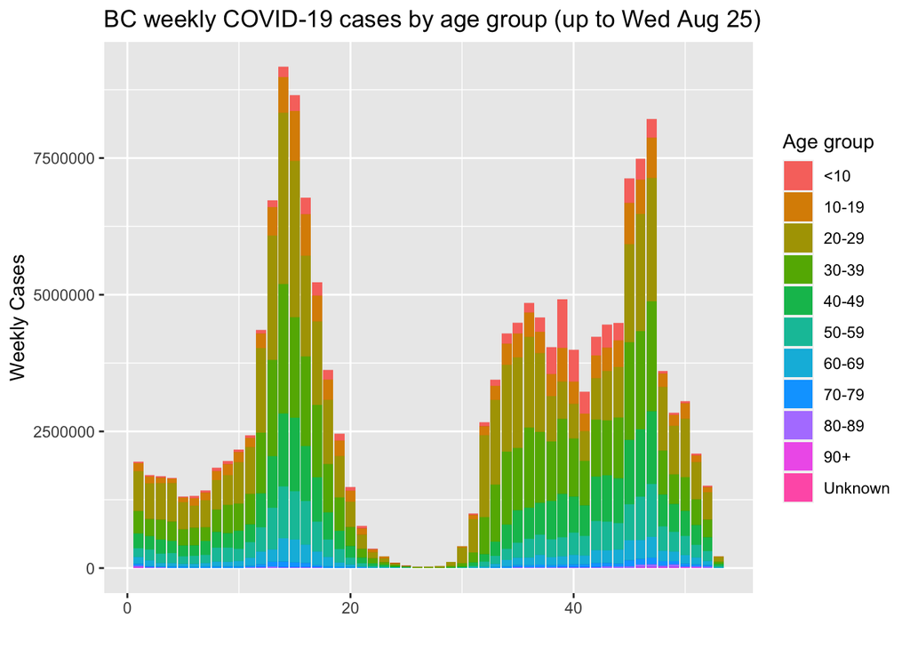

```r
ggplot(plotexp2, aes(x= ref_date, fill = Age_Group)) +
  geom_col(aes(y = numinf1)) + labs(fill = "Age group") +
  #Add Labels & Title
  xlab("") + ylab("Weekly Cases") + ggtitle("BC weekly COVID-19 cases by age group (up to Wed Aug 25)")
```

##### For this project, I will use the code that generated the first image showing our plot on a continuos *x* scale

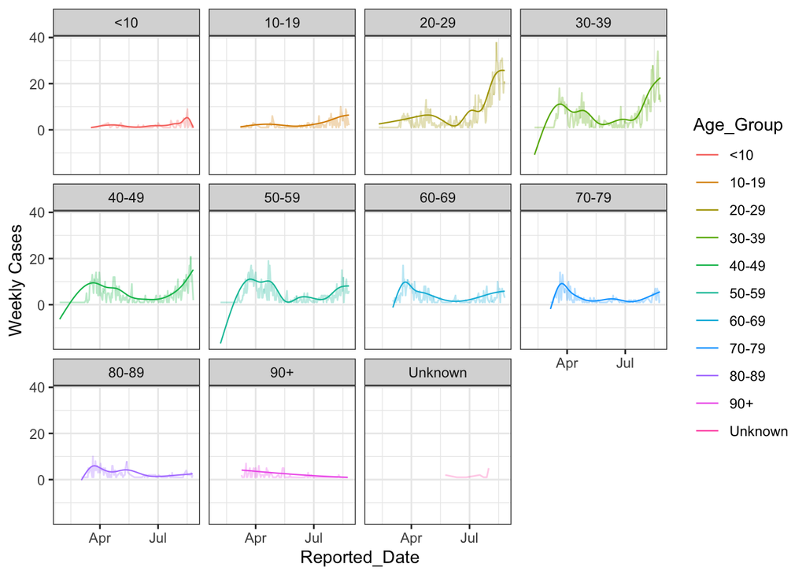

```r
# Line plot and showing different age groups
covplotline <- ggplot(covgg, aes(x= Reported_Date, colour = Age_Group)) +
  geom_line(aes(y= num_inf), alpha = 0.3) +
  geom_smooth(aes(y=num_inf), size=0.4, se= FALSE)+
  facet_wrap(~Age_Group) + theme(legend.position = "bottom") + ylab("Weekly Cases") + theme_bw()
covplotline
```

As we can see, as of 2020-08-25 the were high rates of infection (20+ per day) amongst 20-29 and 30-39 age groups and moderate levels (10+ per day) in 40-49 age group, and later into the pandemic, and high levels (5+ per day) relative to other age groups amongst 30-39 to 80-89 at the start of the pandemic.

We can create a function to efficiently plot multiple data.

```r
# Creating ggplot function
covp <- function(v, d, f) {
       pl <- ggplot(v, aes(x= d, fill = f)) +
  geom_histogram() +
  #Add Labels & Title
  xlab("") + ylab("Weekly Cases") + ggtitle("BC weekly COVID-19 cases by age group (up to Wed Aug 25)")
      return(pl)
}
```

# Working on more recent Data

#### We want to look at cases up till 2021-11-09 to determine the changes over time between our data sets.

Read in the files to be used, but specify dates 2020-01-01 to 2021-11-09.

```r
# Viewing most recent Covid data
covgg2 <- coviddash %>%
  filter(HA != "Out of Canada", Reported_Date >= "2020-01-01", Reported_Date <= "2021-11-09") %>%
  mutate(inf_count = 1) %>% group_by(Reported_Date, Age_Group) %>% summarise(Age_Group, num_inf = sum(inf_count)) %>% ungroup()
covgg2
```

```
## # A tibble: 210,473 × 3
##    Reported_Date Age_Group num_inf
##    <date>        <chr>       <dbl>
##  1 2020-02-06    50-59           1
##  2 2020-02-18    30-39           1
##  3 2020-02-24    30-39           1
##  4 2020-02-24    40-49           1
##  5 2020-03-03    30-39           1
##  6 2020-03-03    50-59           1
##  7 2020-03-03    60-69           2
##  8 2020-03-03    60-69           2
##  9 2020-03-03    80-89           1
## 10 2020-03-05    20-29           1
## # … with 210,463 more rows
```

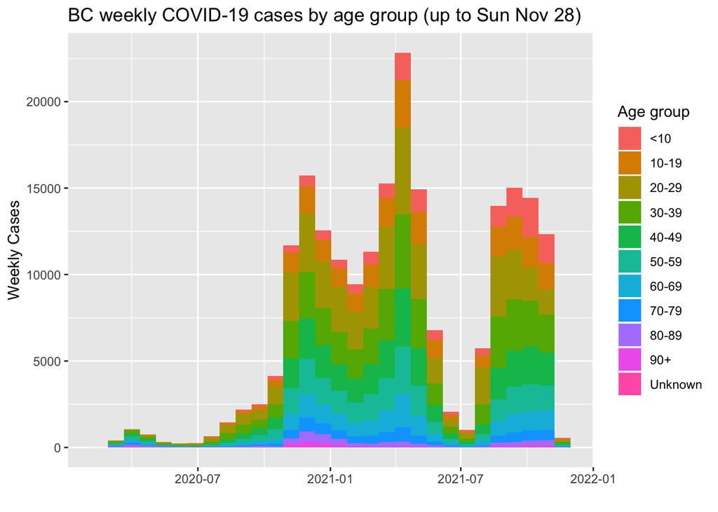

```r
covplot2 <- ggplot(covgg2, aes(x = Reported_Date, fill = Age_Group)) +
  geom_histogram() + labs(fill = "Age group") +
  #Add Labels & Title
  xlab("") + ylab("Weekly Cases") + ggtitle("BC weekly COVID-19 cases by age group (up to Sun Nov 28)")
covplot2
```

Looking at the changes over time in different Age groups.

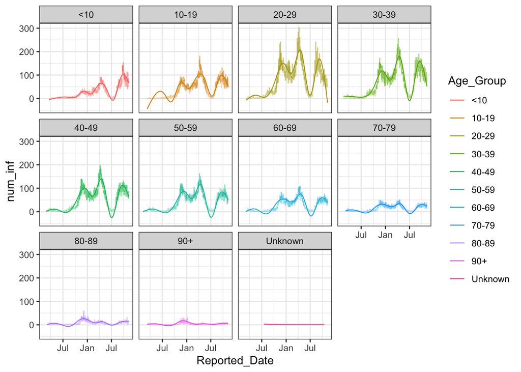

```r
# Line plot and showing different age groups
covplotline2 <- ggplot(covgg2, aes(x= Reported_Date, colour = Age_Group)) +
  geom_line(aes(y= num_inf), alpha = 0.3) +
  geom_smooth(aes(y=num_inf), size=0.4, se= FALSE)+
  facet_wrap(~Age_Group) + theme(legend.position = "bottom") + scale_x_date(date_labels = "%b") + theme_bw()
covplotline2
```

### BC daily cases, adjusted for population

https://twitter.com/vb_jens/status/1325965304925577218?s=20

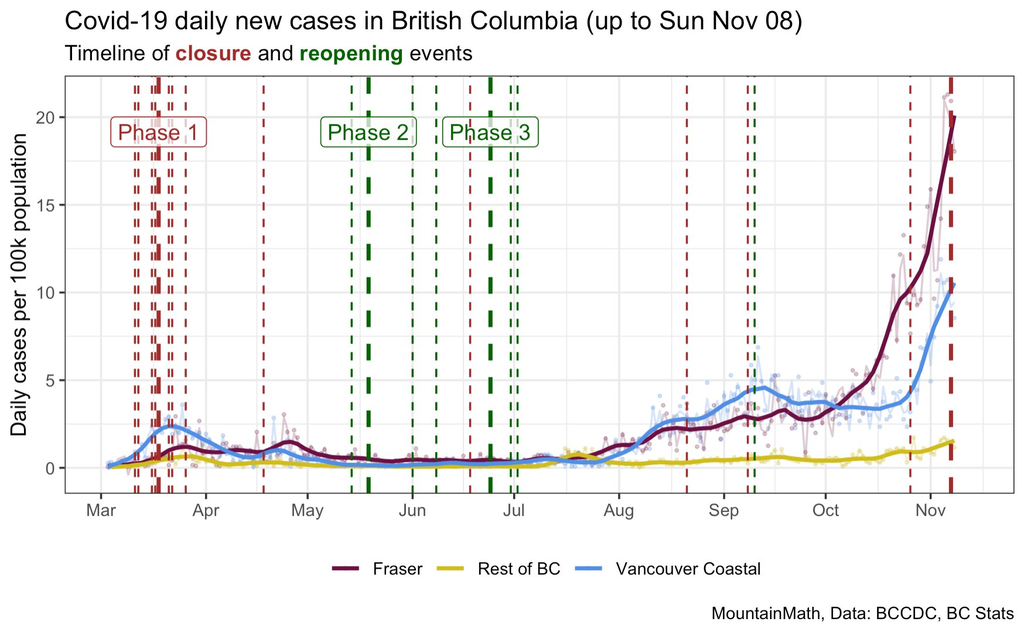

## Other visualizations of data from the same source

https://twitter.com/vb_jens/status/1323423179390418944?s=20

Animations:

https://twitter.com/vb_jens/status/1323649252770291713?s=20

## Data source

Source: COVID-19 Canada Open Data Working Group

[opencovid.ca GitHub repository](https://github.com/jeanpaulrsoucy/covid-19-canada-gov-data)

Current to 2020-11-11 _________________________________________________________________________________________________________________

# WORKING ON QUESTION 2

### Goal: Show the regional daily cases per 100k population over time. Contrast recent data with data obtained on specified date from sample image of graph.

#### Approach:

```
    Create a new column with int 1
    group by health region,
    summarise (tot_case = sum(int 1 col))
    Filter Tot population of each region from Pop est csv
    left join filtered table to covid dash board
    create new variable using total of pop from joined covid dash board
    filter by regions and calculate cases per 100k population for each region
    join tables together
    plot data
```

```r
# WORKING ON QUESTION 2

# Read our csv file in showing population estimates
popest <- read_csv("Population_Estimates.csv", col_names = TRUE)
# Filter out BC and create new variable for gender to be used in left join
popest <- popest %>% mutate(Sex = `Gender`) %>% filter(`Health Authority`!= "British Columbia")
popest
```

```
## # A tibble: 15 × 26
##    Region `Health Authority`  Year Gender   Total   LT1 `1-4`  `5-9` `10-14`
##     <dbl> <chr>              <dbl> <chr>    <dbl> <dbl> <dbl>  <dbl>   <dbl>
##  1      1 Interior            2019 M       413475  3277 14412  19123   19558
##  2      1 Interior            2019 F       413839  2965 13573  18494   19227
##  3      1 Interior            2019 T       827314  6242 27985  37617   38785
##  4      2 Fraser              2019 M       947960  9412 39871  53375   53145
##  5      2 Fraser              2019 F       958973  8823 36878  50019   50989
##  6      2 Fraser              2019 T      1906933 18235 76749 103394  104134
##  7      3 Vancouver Coastal   2019 M       582470  5053 19276  23920   23956
##  8      3 Vancouver Coastal   2019 F       611507  4659 17804  21765   23281
##  9      3 Vancouver Coastal   2019 T      1193977  9712 37080  45685   47237
## 10      4 Vancouver Island    2019 M       420460  3160 14579  19125   19199
## 11      4 Vancouver Island    2019 F       438325  3149 13865  18970   18537
## 12      4 Vancouver Island    2019 T       858785  6309 28444  38095   37736
## 13      5 Northern            2019 M       146424  1378  7015   8775    8596
## 14      5 Northern            2019 F       137903  1443  6526   8237    8169
## 15      5 Northern            2019 T       284327  2821 13541  17012   16765
## # … with 17 more variables: 15-19 <dbl>, 20-24 <dbl>, 25-29 <dbl>, 30-34 <dbl>,
## #   35-39 <dbl>, 40-44 <dbl>, 45-49 <dbl>, 50-54 <dbl>, 55-59 <dbl>,
## #   60-64 <dbl>, 65-69 <dbl>, 70-74 <dbl>, 75-79 <dbl>, 80-84 <dbl>,
## #   85-89 <dbl>, 90+ <dbl>, Sex <chr>
```

```r
#Select new table
popest <- popest %>% select("Region" : "Year","Sex","Total":"90+")
popest
```

```
## # A tibble: 15 × 25
##    Region `Health Authority`  Year Sex    Total   LT1 `1-4`  `5-9` `10-14` `15-19`
##     <dbl> <chr>              <dbl> <chr>  <dbl> <dbl> <dbl>  <dbl>   <dbl>   <dbl>
##  1      1 Interior            2019 M     4.13e5  3277 14412  19123   19558   21184
##  2      1 Interior            2019 F     4.14e5  2965 13573  18494   19227   19709
##  3      1 Interior            2019 T     8.27e5  6242 27985  37617   38785   40893
##  4      2 Fraser              2019 M     9.48e5  9412 39871  53375   53145   60912
##  5      2 Fraser              2019 F     9.59e5  8823 36878  50019   50989   57911
##  6      2 Fraser              2019 T     1.91e6 18235 76749 103394  104134  118823
##  7      3 Vancouver Coastal   2019 M     5.82e5  5053 19276  23920   23956   30164
##  8      3 Vancouver Coastal   2019 F     6.12e5  4659 17804  21765   23281   29273
##  9      3 Vancouver Coastal   2019 T     1.19e6  9712 37080  45685   47237   59437
## 10      4 Vancouver Island    2019 M     4.20e5  3160 14579  19125   19199   20941
## 11      4 Vancouver Island    2019 F     4.38e5  3149 13865  18970   18537   20418
## 12      4 Vancouver Island    2019 T     8.59e5  6309 28444  38095   37736   41359
## 13      5 Northern            2019 M     1.46e5  1378  7015   8775    8596    8530
## 14      5 Northern            2019 F     1.38e5  1443  6526   8237    8169    8080
## 15      5 Northern            2019 T     2.84e5  2821 13541  17012   16765   16610
## # … with 15 more variables: 20-24 <dbl>, 25-29 <dbl>, 30-34 <dbl>, 35-39 <dbl>,
## #   40-44 <dbl>, 45-49 <dbl>, 50-54 <dbl>, 55-59 <dbl>, 60-64 <dbl>,
## #   65-69 <dbl>, 70-74 <dbl>, 75-79 <dbl>, 80-84 <dbl>, 85-89 <dbl>, 90+ <dbl>
```

```r
# Read files for our covid cases
coviddash2 <- read_csv("BCCDC_COVID19_Dashboard_Case_Details_2021-11-28_22-02.csv", col_names = TRUE)
covinfreq2 <- coviddash2 %>% filter(Reported_Date >= "2020-01-01", Reported_Date <= "2020-11-09")
```

Reading files in to our environment.

```r
# Get Total population of each region
totpop <- popest %>% mutate(HA = `Health Authority`) %>% group_by(HA) %>% select(HA, Total, Sex) %>% filter(Sex == "T") %>% select(HA, Total)
totpop
```

```
## # A tibble: 5 × 2
## # Groups:   HA [5]
##   HA                  Total
##   <chr>               <dbl>
## 1 Interior           827314
## 2 Fraser            1906933
## 3 Vancouver Coastal 1193977
## 4 Vancouver Island   858785
## 5 Northern           284327
```

We have analyzed the data to obtain the total populations in each region by filtering our data.

```r
# Total Cases by Region
regcase <- covinfreq2 %>% group_by(HA) %>% mutate(casecount = 1) %>% mutate(casescov = sum(casecount)) %>% distinct(HA, casescov)
regcase
```

```
## # A tibble: 6 × 2
## # Groups:   HA [6]
##   HA                casescov
##   <chr>                <dbl>
## 1 Out of Canada           89
## 2 Vancouver Coastal     5858
## 3 Interior               965
## 4 Fraser               11823
## 5 Northern               477
## 6 Vancouver Island       310
```

We have analyzed the data to obtain the total number of cases in each region. Fraser and Vancouver Coastal had the most cases at 11,823 and 5,858 cases respectively.

```r
# Daily Cases
daycase <- covinfreq2 %>% group_by(Reported_Date, HA) %>% mutate(countah = 1) %>% summarise(totcountah = sum(countah)) %>% ungroup()
daycase
```

```
## # A tibble: 995 × 3
##    Reported_Date HA                totcountah
##    <date>        <chr>                  <dbl>
##  1 2020-01-29    Out of Canada              1
##  2 2020-02-06    Vancouver Coastal          1
##  3 2020-02-10    Out of Canada              2
##  4 2020-02-18    Interior                   1
##  5 2020-02-24    Fraser                     2
##  6 2020-03-03    Fraser                     1
##  7 2020-03-03    Vancouver Coastal          4
##  8 2020-03-05    Fraser                     1
##  9 2020-03-05    Out of Canada              3
## 10 2020-03-05    Vancouver Coastal          4
## # … with 985 more rows
```

We have calculated the total number of cases daily

```r
# Joining tables into one data set
threejoins <- daycase %>% left_join(regcase, by = "HA") %>% left_join(totpop, by = "HA")
threejoins
```

```
## # A tibble: 995 × 5
##    Reported_Date HA                totcountah casescov   Total
##    <date>        <chr>                  <dbl>    <dbl>   <dbl>
##  1 2020-01-29    Out of Canada              1       89      NA
##  2 2020-02-06    Vancouver Coastal          1     5858 1193977
##  3 2020-02-10    Out of Canada              2       89      NA
##  4 2020-02-18    Interior                   1      965  827314
##  5 2020-02-24    Fraser                     2    11823 1906933
##  6 2020-03-03    Fraser                     1    11823 1906933
##  7 2020-03-03    Vancouver Coastal          4     5858 1193977
##  8 2020-03-05    Fraser                     1    11823 1906933
##  9 2020-03-05    Out of Canada              3       89      NA
## 10 2020-03-05    Vancouver Coastal          4     5858 1193977
## # … with 985 more rows
```

We have combined 3 new objects to make a data set showing dates, health authority, daily cases, total number of cases, and total population of each region.

## Further analysis

Now we do some further analysis to calculate the daily cases per 100k population.

```r
# Calculating daily cases per 100k population and group by date, Health Authority & cases
caseplot <- threejoins %>% mutate(case100k = (Total/100000)) %>% mutate(case100k = totcountah/case100k) %>% group_by(Reported_Date) %>% select(Reported_Date, HA, case100k)
caseplot
```

```
## # A tibble: 995 × 3
## # Groups:   Reported_Date [256]
##    Reported_Date HA                case100k
##    <date>        <chr>                <dbl>
##  1 2020-01-29    Out of Canada      NA
##  2 2020-02-06    Vancouver Coastal   0.0838
##  3 2020-02-10    Out of Canada      NA
##  4 2020-02-18    Interior            0.121
##  5 2020-02-24    Fraser              0.105
##  6 2020-03-03    Fraser              0.0524
##  7 2020-03-03    Vancouver Coastal   0.335
##  8 2020-03-05    Fraser              0.0524
##  9 2020-03-05    Out of Canada      NA
## 10 2020-03-05    Vancouver Coastal   0.335
## # … with 985 more rows
```

Our new variable *case100k* is now added to our data showing the daily cases per 100k. This calculation uses the total population of each region / 100000, and then divides daily case count using this value to obtain the 100K case count.

```r
# Change regions to "Rest of BC"
caseplot <- caseplot %>% mutate(HA = case_when(HA == "Vancouver Coastal" ~ "Vancouver Coastal",
                                   HA == "Fraser" ~ "Fraser",
                                   HA == "Out of Canada" ~ "Out of Canada",
                                   TRUE ~ "Rest of BC"))
caseplot
```

```
## # A tibble: 995 × 3
## # Groups:   Reported_Date [256]
##    Reported_Date HA                case100k
##    <date>        <chr>                <dbl>
##  1 2020-01-29    Out of Canada      NA
##  2 2020-02-06    Vancouver Coastal   0.0838
##  3 2020-02-10    Out of Canada      NA
##  4 2020-02-18    Rest of BC          0.121
##  5 2020-02-24    Fraser              0.105
##  6 2020-03-03    Fraser              0.0524
##  7 2020-03-03    Vancouver Coastal   0.335
##  8 2020-03-05    Fraser              0.0524
##  9 2020-03-05    Out of Canada      NA
## 10 2020-03-05    Vancouver Coastal   0.335
## # … with 985 more rows
```

Now we have a tibble with dates, health authorities, and cases per 100k population.

Now we filter data to remove “Out of Canada” values from our data, while specifying the date ranges we want for our analysis.

```r
# Filter data to include Health Authorities for Canada and Dates
caseplot <- caseplot %>% filter(HA != "Out of Canada") %>% filter(Reported_Date >= "2020-01-01", Reported_Date <= "2020-11-09")
tail(caseplot)
```

```
## # A tibble: 6 × 3
## # Groups:   Reported_Date [2]
##   Reported_Date HA                case100k
##   <date>        <chr>                <dbl>
## 1 2020-11-08    Rest of BC           1.05
## 2 2020-11-09    Fraser              16.5
## 3 2020-11-09    Rest of BC           3.75
## 4 2020-11-09    Rest of BC           0.703
## 5 2020-11-09    Vancouver Coastal   11.9
## 6 2020-11-09    Rest of BC           0.932
```

Now we filter data for just “Rest of BC” values and creating a variable for our filter.

```r
# Creating a variable for rest of bc values
caseplotbc <- caseplot %>% filter(HA == "Rest of BC") %>% mutate(case100k_bc = case100k) %>% select(Reported_Date, HA, case100k_bc)
caseplotbc
```

```
## # A tibble: 445 × 3
## # Groups:   Reported_Date [207]
##    Reported_Date HA         case100k_bc
##    <date>        <chr>            <dbl>
##  1 2020-02-18    Rest of BC       0.121
##  2 2020-03-08    Rest of BC       0.352
##  3 2020-03-09    Rest of BC       0.352
##  4 2020-03-10    Rest of BC       0.116
##  5 2020-03-13    Rest of BC       0.116
##  6 2020-03-14    Rest of BC       0.352
##  7 2020-03-14    Rest of BC       0.349
##  8 2020-03-15    Rest of BC       0.242
##  9 2020-03-15    Rest of BC       0.349
## 10 2020-03-16    Rest of BC       0.242
## # … with 435 more rows
```

Now we filter data for just “Fraser” values and creating a variable for our filter.

```r
# Creating a variable for Fraser values
caseplotfr <- caseplot %>% filter(HA == "Fraser") %>% mutate(case100k_fr = case100k) %>% select(Reported_Date, HA, case100k_fr)
caseplotfr
```

```
## # A tibble: 249 × 3
## # Groups:   Reported_Date [249]
##    Reported_Date HA     case100k_fr
##    <date>        <chr>        <dbl>
##  1 2020-02-24    Fraser      0.105
##  2 2020-03-03    Fraser      0.0524
##  3 2020-03-05    Fraser      0.0524
##  4 2020-03-06    Fraser      0.210
##  5 2020-03-08    Fraser      0.157
##  6 2020-03-10    Fraser      0.262
##  7 2020-03-11    Fraser      0.157
##  8 2020-03-13    Fraser      0.0524
##  9 2020-03-14    Fraser      0.315
## 10 2020-03-15    Fraser      0.524
## # … with 239 more rows
```

Now we filter data for just “Vancouver Coastal” values and creating a variable for our filter.

```r
# Creating variable for Vancouver Coastal values
caseplotvc <- caseplot %>% filter(HA == "Vancouver Coastal") %>% mutate(case100k_vc = case100k) %>% select(Reported_Date, HA, case100k_vc)
caseplotvc
```

```
## # A tibble: 234 × 3
## # Groups:   Reported_Date [234]
##    Reported_Date HA                case100k_vc
##    <date>        <chr>                   <dbl>
##  1 2020-02-06    Vancouver Coastal      0.0838
##  2 2020-03-03    Vancouver Coastal      0.335
##  3 2020-03-05    Vancouver Coastal      0.335
##  4 2020-03-06    Vancouver Coastal      0.251
##  5 2020-03-07    Vancouver Coastal      0.0838
##  6 2020-03-09    Vancouver Coastal      0.168
##  7 2020-03-10    Vancouver Coastal      0.335
##  8 2020-03-11    Vancouver Coastal      1.09
##  9 2020-03-12    Vancouver Coastal      0.670
## 10 2020-03-13    Vancouver Coastal      1.17
## # … with 224 more rows
```

Now we join the 3 new tables into the original data set to create a new table showing daily cases count per 100k population for each region for our analysis

```r
# Join the 3 tables into original data set to create new data
caseplotgg <- caseplot %>% left_join(caseplotbc, by = c("Reported_Date", "HA")) %>% left_join(caseplotfr, by = c("Reported_Date", "HA")) %>% left_join(caseplotvc, by = c("Reported_Date", "HA")) %>% select(Reported_Date, HA, case100k_bc : case100k_vc)
caseplotgg
```

```
## # A tibble: 1,576 × 5
## # Groups:   Reported_Date [254]
##    Reported_Date HA                case100k_bc case100k_fr case100k_vc
##    <date>        <chr>                   <dbl>       <dbl>       <dbl>
##  1 2020-02-06    Vancouver Coastal      NA         NA           0.0838
##  2 2020-02-18    Rest of BC              0.121     NA          NA
##  3 2020-02-24    Fraser                 NA          0.105      NA
##  4 2020-03-03    Fraser                 NA          0.0524     NA
##  5 2020-03-03    Vancouver Coastal      NA         NA           0.335
##  6 2020-03-05    Fraser                 NA          0.0524     NA
##  7 2020-03-05    Vancouver Coastal      NA         NA           0.335
##  8 2020-03-06    Fraser                 NA          0.210      NA
##  9 2020-03-06    Vancouver Coastal      NA         NA           0.251
## 10 2020-03-07    Vancouver Coastal      NA         NA           0.0838
## # … with 1,566 more rows
```

### We plot our data on a line graph to show the changes over time.

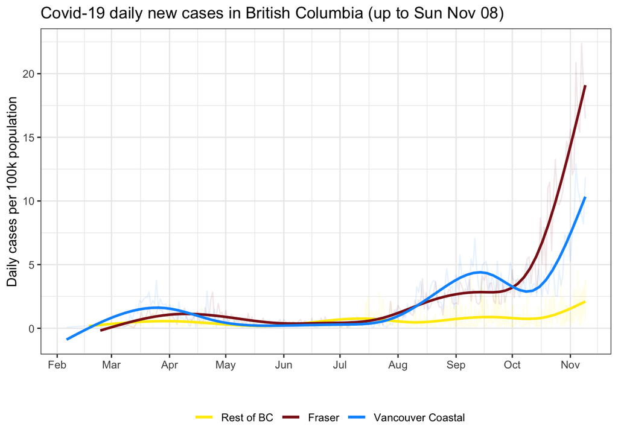

```r
# Plotting newly created Data
casegg <- ggplot(caseplotgg, aes(x = Reported_Date)) +
  geom_line(aes(y = case100k_bc, colour = HA), alpha = 0.1) +
  geom_line(aes(y = case100k_fr, colour = HA), alpha = 0.1) +
  geom_line(aes(y = case100k_vc, colour = HA), alpha = 0.1) +
  geom_smooth(aes(y = case100k_bc, colour = "Rest of BC"), se = FALSE) +
  geom_smooth(aes(y = case100k_fr, colour = "Fraser"), se = FALSE) +
  geom_smooth(aes(y = case100k_vc, colour = "Vancouver Coastal"), se = FALSE) +
  # Adding Labels
  xlab("") + ylab("Daily cases per 100k population") +
  # Adding titles
  ggtitle("Covid-19 daily new cases in British Columbia (up to Sun Nov 08)") +
  # Adding colours
  scale_colour_manual("", values=c("Rest of BC"="#FFEA00", "Fraser"="firebrick4", "Vancouver Coastal"="#0096FF")) +
  # Changing date scale for x variable on graph
  scale_x_date(date_labels = "%b", date_breaks = "1 month") +
  # Changing theme and legend position
  theme_bw() + theme(legend.position = "bottom")

# View plot
casegg
```

To view the different regions,

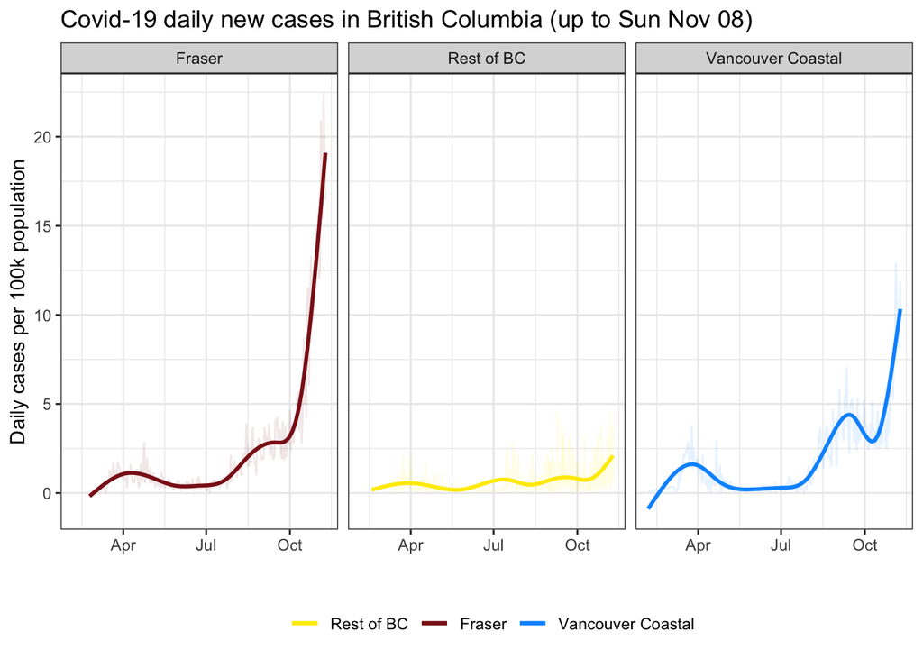

```r
# View separate regions
reg_case <- casegg + facet_wrap(~HA) + scale_x_date(date_breaks = "3 months", date_labels = "%b") + theme(legend.position = "bottom")
reg_case
```

Analyzing the graphs for each region, Fraser and Vancouver saw spikes in daily cases in contrast to the rest of BC. Fraser and Vancouver Coastal as of 2020-11-09 were reporting over 15 and 10 cases daily respectively, while the rest of BC barely had 5 daily cases.

## Working on recent data as of 2021-11-28

We read our data in while filtering and specifying dates and assigning the results to an object.

```r
# Total Pop of infected in each region
covinfreq_rec <- coviddash2 %>% filter(Reported_Date >= "2020-01-01", Reported_Date <= "2021-11-28") %>% filter(HA != "Out of Canada")

covinfreq_rec
```

```
## # A tibble: 216,799 × 5
##    Reported_Date HA                Sex   Age_Group Classification_Reported
##    <date>        <chr>             <chr> <chr>     <chr>
##  1 2020-02-06    Vancouver Coastal F     50-59     Lab-diagnosed
##  2 2020-02-18    Interior          F     30-39     Lab-diagnosed
##  3 2020-02-24    Fraser            M     40-49     Lab-diagnosed
##  4 2020-02-24    Fraser            F     30-39     Lab-diagnosed
##  5 2020-03-03    Fraser            M     50-59     Lab-diagnosed
##  6 2020-03-03    Vancouver Coastal F     60-69     Lab-diagnosed
##  7 2020-03-03    Vancouver Coastal F     30-39     Lab-diagnosed
##  8 2020-03-03    Vancouver Coastal M     60-69     Lab-diagnosed
##  9 2020-03-03    Vancouver Coastal F     80-89     Lab-diagnosed
## 10 2020-03-05    Fraser            F     50-59     Lab-diagnosed
## # … with 216,789 more rows
```

```r
tail(covinfreq_rec)
```

```
## # A tibble: 6 × 5
##   Reported_Date HA               Sex   Age_Group Classification_Reported
##   <date>        <chr>            <chr> <chr>     <chr>
## 1 2021-11-25    Interior         F     10-19     Lab-diagnosed
## 2 2021-11-25    Vancouver Island M     20-29     Lab-diagnosed
## 3 2021-11-25    Interior         F     50-59     Lab-diagnosed
## 4 2021-11-25    Interior         M     <10       Lab-diagnosed
## 5 2021-11-25    Vancouver Island M     10-19     Lab-diagnosed
## 6 2021-11-25    Northern         M     80-89     Lab-diagnosed
```

Get total number of cases in each region

```r
# Total Cases by Region
regcase_rec <- covinfreq_rec %>% group_by(HA) %>% mutate(casecount = 1) %>% mutate(casescov = sum(casecount)) %>% distinct(HA, casescov)
regcase_rec
```

```
## # A tibble: 5 × 2
## # Groups:   HA [5]
##   HA                casescov
##   <chr>                <dbl>
## 1 Vancouver Coastal    44821
## 2 Interior             33245
## 3 Fraser              108926
## 4 Northern             17390
## 5 Vancouver Island     12417
```

Get the number of daily cases

```r
# Daily Cases
daycase_rec <- covinfreq_rec %>% group_by(Reported_Date, HA) %>% mutate(countah = 1) %>% summarise(totcountah = sum(countah)) %>% ungroup()
daycase_rec
```

```
## # A tibble: 2,808 × 3
##    Reported_Date HA                totcountah
##    <date>        <chr>                  <dbl>
##  1 2020-02-06    Vancouver Coastal          1
##  2 2020-02-18    Interior                   1
##  3 2020-02-24    Fraser                     2
##  4 2020-03-03    Fraser                     1
##  5 2020-03-03    Vancouver Coastal          4
##  6 2020-03-05    Fraser                     1
##  7 2020-03-05    Vancouver Coastal          4
##  8 2020-03-06    Fraser                     4
##  9 2020-03-06    Vancouver Coastal          3
## 10 2020-03-07    Vancouver Coastal          1
## # … with 2,798 more rows
```

Combine our results into one data set. We join the number of daily cases, region cases, and total population of each region into one table.

```r
# Joining tables into one data set
threejoins_rec <- daycase_rec %>% left_join(regcase, by = "HA") %>% left_join(totpop, by = "HA") %>% ungroup()
threejoins_rec
```

```
## # A tibble: 2,808 × 5
##    Reported_Date HA                totcountah casescov   Total
##    <date>        <chr>                  <dbl>    <dbl>   <dbl>
##  1 2020-02-06    Vancouver Coastal          1     5858 1193977
##  2 2020-02-18    Interior                   1      965  827314
##  3 2020-02-24    Fraser                     2    11823 1906933
##  4 2020-03-03    Fraser                     1    11823 1906933
##  5 2020-03-03    Vancouver Coastal          4     5858 1193977
##  6 2020-03-05    Fraser                     1    11823 1906933
##  7 2020-03-05    Vancouver Coastal          4     5858 1193977
##  8 2020-03-06    Fraser                     4    11823 1906933
##  9 2020-03-06    Vancouver Coastal          3     5858 1193977
## 10 2020-03-07    Vancouver Coastal          1     5858 1193977
## # … with 2,798 more rows
```

Calculating the daily cases per 100k population of all Health Authorities

```r
# Calculating daily cases per 100k population and group by date, Health Authority & cases
caseplot_rec <- threejoins_rec %>% mutate(case100k = (Total/100000)) %>% mutate(case100k = totcountah/case100k) %>% group_by(Reported_Date) %>% select(Reported_Date, HA, case100k) %>% ungroup()
caseplot_rec
```

```
## # A tibble: 2,808 × 3
##    Reported_Date HA                case100k
##    <date>        <chr>                <dbl>
##  1 2020-02-06    Vancouver Coastal   0.0838
##  2 2020-02-18    Interior            0.121
##  3 2020-02-24    Fraser              0.105
##  4 2020-03-03    Fraser              0.0524
##  5 2020-03-03    Vancouver Coastal   0.335
##  6 2020-03-05    Fraser              0.0524
##  7 2020-03-05    Vancouver Coastal   0.335
##  8 2020-03-06    Fraser              0.210
##  9 2020-03-06    Vancouver Coastal   0.251
## 10 2020-03-07    Vancouver Coastal   0.0838
## # … with 2,798 more rows
```

```r
# Change regions to "Rest of BC"
caseplot_rec <- caseplot_rec %>% mutate(HA = case_when(HA == "Vancouver Coastal" ~ "Vancouver Coastal",
                                                       HA == "Fraser" ~ "Fraser",
                                                       HA == "Out of Canada" ~ "Out of Canada",
                                                       TRUE ~ "Rest of BC"))
caseplot_rec
```

```
## # A tibble: 2,808 × 3
##    Reported_Date HA                case100k
##    <date>        <chr>                <dbl>
##  1 2020-02-06    Vancouver Coastal   0.0838
##  2 2020-02-18    Rest of BC          0.121
##  3 2020-02-24    Fraser              0.105
##  4 2020-03-03    Fraser              0.0524
##  5 2020-03-03    Vancouver Coastal   0.335
##  6 2020-03-05    Fraser              0.0524
##  7 2020-03-05    Vancouver Coastal   0.335
##  8 2020-03-06    Fraser              0.210
##  9 2020-03-06    Vancouver Coastal   0.251
## 10 2020-03-07    Vancouver Coastal   0.0838
## # … with 2,798 more rows
```

Filtering our data to remove “Out of Canada” and specify dates uptil 2021-11-28 and assigning the result to an object

```r
# Filter data to include Health Authorities for Canada and Dates
caseplot_rec <- caseplot_rec %>% filter(HA != "Out of Canada") %>% filter(Reported_Date >= "2020-01-01", Reported_Date <= "2021-11-28")
tail(caseplot_rec)
```

```
## # A tibble: 6 × 3
##   Reported_Date HA                case100k
##   <date>        <chr>                <dbl>
## 1 2021-11-24    Rest of BC            7.57
## 2 2021-11-25    Fraser                4.93
## 3 2021-11-25    Rest of BC            8.70
## 4 2021-11-25    Rest of BC           10.6
## 5 2021-11-25    Vancouver Coastal     4.86
## 6 2021-11-25    Rest of BC            7.45
```

Now we filter data for just “Rest of BC” values and creating a variable for our filter.

```r
# Creating a variable for rest of bc values
caseplotbc_rec <- caseplot_rec %>% filter(HA == "Rest of BC") %>% mutate(case100k_bc = case100k) %>% select(Reported_Date, HA, case100k_bc)
caseplotbc_rec
```

```
## # A tibble: 1,563 × 3
##    Reported_Date HA         case100k_bc
##    <date>        <chr>            <dbl>
##  1 2020-02-18    Rest of BC       0.121
##  2 2020-03-08    Rest of BC       0.352
##  3 2020-03-09    Rest of BC       0.352
##  4 2020-03-10    Rest of BC       0.116
##  5 2020-03-13    Rest of BC       0.116
##  6 2020-03-14    Rest of BC       0.352
##  7 2020-03-14    Rest of BC       0.349
##  8 2020-03-15    Rest of BC       0.242
##  9 2020-03-15    Rest of BC       0.349
## 10 2020-03-16    Rest of BC       0.242
## # … with 1,553 more rows
```

Now we filter data for just “Fraser” values and creating a variable for our filter.

```r
# Creating a variable for Fraser values
caseplotfr_rec <- caseplot_rec %>% filter(HA == "Fraser") %>% mutate(case100k_fr = case100k) %>% select(Reported_Date, HA, case100k_fr)
caseplotfr_rec
```

```
## # A tibble: 630 × 3
##    Reported_Date HA     case100k_fr
##    <date>        <chr>        <dbl>
##  1 2020-02-24    Fraser      0.105
##  2 2020-03-03    Fraser      0.0524
##  3 2020-03-05    Fraser      0.0524
##  4 2020-03-06    Fraser      0.210
##  5 2020-03-08    Fraser      0.157
##  6 2020-03-10    Fraser      0.262
##  7 2020-03-11    Fraser      0.157
##  8 2020-03-13    Fraser      0.0524
##  9 2020-03-14    Fraser      0.315
## 10 2020-03-15    Fraser      0.524
## # … with 620 more rows
```

Now we filter data for just “Vancouver Coastal” values and creating a variable for our filter.

```r
# Creating variable for Vancouver Coastal values
caseplotvc_rec <- caseplot_rec %>% filter(HA == "Vancouver Coastal") %>% mutate(case100k_vc = case100k) %>% select(Reported_Date, HA, case100k_vc)
caseplotvc_rec
```

```
## # A tibble: 615 × 3
##    Reported_Date HA                case100k_vc
##    <date>        <chr>                   <dbl>
##  1 2020-02-06    Vancouver Coastal      0.0838
##  2 2020-03-03    Vancouver Coastal      0.335
##  3 2020-03-05    Vancouver Coastal      0.335
##  4 2020-03-06    Vancouver Coastal      0.251
##  5 2020-03-07    Vancouver Coastal      0.0838
##  6 2020-03-09    Vancouver Coastal      0.168
##  7 2020-03-10    Vancouver Coastal      0.335
##  8 2020-03-11    Vancouver Coastal      1.09
##  9 2020-03-12    Vancouver Coastal      0.670
## 10 2020-03-13    Vancouver Coastal      1.17
## # … with 605 more rows
```

Combine all tables into original data set

```r
# Join the 3 tables into original data set to create new data
caseplotgg_rec <- caseplot_rec %>% left_join(caseplotbc_rec, by = c("Reported_Date", "HA")) %>% left_join(caseplotfr_rec, by = c("Reported_Date", "HA")) %>% left_join(caseplotvc_rec, by = c("Reported_Date", "HA")) %>% select(Reported_Date, HA, case100k_bc : case100k_vc) %>% ungroup()
caseplotgg_rec
```

```
## # A tibble: 5,652 × 5
##    Reported_Date HA                case100k_bc case100k_fr case100k_vc
##    <date>        <chr>                   <dbl>       <dbl>       <dbl>
##  1 2020-02-06    Vancouver Coastal      NA         NA           0.0838
##  2 2020-02-18    Rest of BC              0.121     NA          NA
##  3 2020-02-24    Fraser                 NA          0.105      NA
##  4 2020-03-03    Fraser                 NA          0.0524     NA
##  5 2020-03-03    Vancouver Coastal      NA         NA           0.335
##  6 2020-03-05    Fraser                 NA          0.0524     NA
##  7 2020-03-05    Vancouver Coastal      NA         NA           0.335
##  8 2020-03-06    Fraser                 NA          0.210      NA
##  9 2020-03-06    Vancouver Coastal      NA         NA           0.251
## 10 2020-03-07    Vancouver Coastal      NA         NA           0.0838
## # … with 5,642 more rows
```

# Plotting recent data

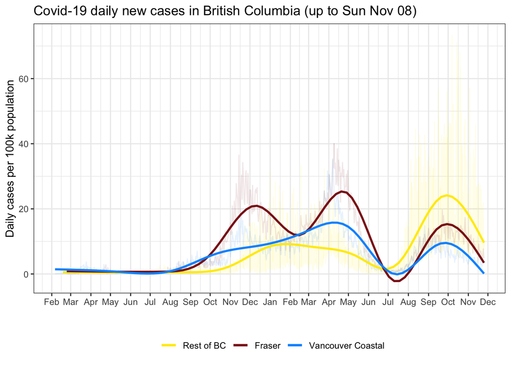

```r
# Plotting newly created Data
casegg_rec <- ggplot(caseplotgg_rec, aes(x = Reported_Date)) +
  geom_line(aes(y = case100k_bc, colour = HA), alpha = 0.1) +
  geom_line(aes(y = case100k_fr, colour = HA), alpha = 0.1) +
  geom_line(aes(y = case100k_vc, colour = HA), alpha = 0.1) +
  geom_smooth(aes(y = case100k_bc, colour = "Rest of BC"), se = FALSE) +
  geom_smooth(aes(y = case100k_fr, colour = "Fraser"), se = FALSE) +
  geom_smooth(aes(y = case100k_vc, colour = "Vancouver Coastal"), se = FALSE) +
  # Adding Labels
  xlab("") + ylab("Daily cases per 100k population") +
  # Adding titles
  ggtitle("Covid-19 daily new cases in British Columbia (up to Sun Nov 08)") +
  # Adding colours
  scale_colour_manual("", values=c("Rest of BC"="#FFEA00", "Fraser"="firebrick4", "Vancouver Coastal"="#0096FF")) +
  # Changing date scale for x variable on graph
  scale_x_date(date_labels = "%b", date_breaks = "1 month") +
  # Changing theme and legend position
  theme_bw() + theme(legend.position = "bottom")

# View plot
casegg_rec
```

View seperate regions

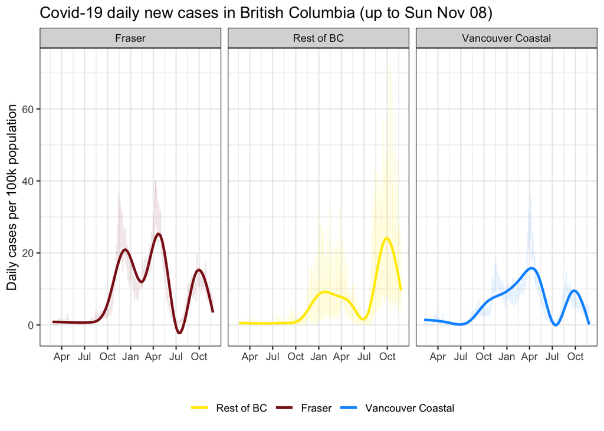

```r
# View separate regions
reg_case_ytd <- casegg_rec + facet_wrap(~HA) + scale_x_date(date_breaks = "3 months", date_labels = "%b") + theme(legend.position = "bottom")
reg_case_ytd
```

As we can see, the cases of Covid have been decreasing, but there was a spike across the rest of BC in contrast to Fraser and Vancouver Coastal regions. Vancouver Coastal seems to be reporting the lowest daily cases, while the rest of BC is reporting high levels relative to the start of the pandemic.

-30-